```python
from income_statement import IncomeStatement
import pandas as pd
import dtale
```

```python
transactions = pd.read_csv('transactions.csv')
accounts = pd.read_csv('accounts.csv')
monthly_statement = IncomeStatement('transactions.csv', 'accounts.csv').get_report()
```

# Data Quality

#### For quick exploratory data analysis to spot check for data quality issues, I like to use the dtale package.

```python
dtale.show(transactions)
```

[interactive chart not shown]

### Using the dtale package, we can quickly see some of the issues in the transaction dataset.

#### 1) There are 13 rows in the transaction file that have been duplicated.

[figure not shown]

#### 2) Looking at a QQ plot, we see three outlier amounts that may be data quality issues and warrant further investigating (also highlighted in red above). The highest value in particular is almost one order of magnitude larger thanthe rest of the amounts in the data set.

[figure not shown]

#### Based on these findings, a quick data quality recommendation for the client would be to add some basic data quality checks to the process that generates the files they send us. Duplicates rows and outlier values are attributes that are relatively easy to detect. Other suggestions for the client would be to standardize the naming of their filenames and column names to a uniform naming convention.

# Data Trends

```python
from IPython.display import HTML
import plotly.graph_objects as go
```

```python
monthly_statement
```

| transaction_month | revenue | cost_of_revenue | gross_profit | gross_margin | operational_expenses | net_income |
| --- | --- | --- | --- | --- | --- | --- |
| 2019-01 | 1031437.67 | 626463.14 | 404974.53 | 0.39 | 1986880.79 | -1581906.26 |
| 2019-02 | 1179373.21 | 881038.33 | 298334.88 | 0.25 | 1680709.50 | -1382374.62 |
| 2019-03 | 1012066.46 | 918445.93 | 93620.53 | 0.09 | 1915225.38 | -1821604.85 |
| 2019-04 | 1159220.50 | 1213241.95 | -54021.45 | -0.05 | 2129930.87 | -2183952.32 |
| 2019-05 | 1053017.97 | 1063737.56 | -10719.59 | -0.01 | 2286592.39 | -2297311.98 |
| 2019-06 | 1497357.19 | 1205354.06 | 292003.13 | 0.20 | 2361428.79 | -2069425.66 |
| 2019-07 | 1976921.01 | 1101067.19 | 875853.82 | 0.44 | 2348116.85 | -1472263.03 |
| 2019-08 | 2021190.68 | 1393655.34 | 627535.34 | 0.31 | 2649732.57 | -2022197.23 |
| 2019-09 | 4479770.85 | 1416536.84 | 3063234.01 | 0.68 | 2781458.71 | 281775.30 |
| 2019-10 | 4346250.50 | 1795045.96 | 2551204.54 | 0.59 | 2506554.08 | 44650.46 |
| 2019-11 | 2148931.10 | 1628328.44 | 520602.66 | 0.24 | 2583476.90 | -2062874.24 |
| 2019-12 | 2575656.83 | 1597717.74 | 977939.09 | 0.38 | 2422424.66 | -1444485.57 |
| 2020-01 | 2616778.49 | 1876248.49 | 740530.00 | 0.28 | 2629866.42 | -1889336.42 |
| 2020-02 | 2368894.91 | 1913524.68 | 455370.23 | 0.19 | 2584453.52 | -2129083.29 |
| 2020-03 | 2876725.40 | 1930765.82 | 945959.58 | 0.33 | 2353939.96 | -1407980.38 |
| 2020-04 | 2704180.99 | 2248029.75 | 456151.24 | 0.17 | 2713384.91 | -2257233.67 |
| 2020-05 | 21159582.78 | 2018981.93 | 19140600.85 | 0.90 | 2527944.63 | 16612656.22 |
| 2020-06 | 3040729.81 | 2054347.48 | 986382.33 | 0.32 | 2543846.02 | -1557463.69 |
| 2020-07 | 3015982.82 | 2177512.73 | 838470.09 | 0.28 | 3297474.52 | -2459004.43 |
| 2020-08 | 3376938.62 | 2546441.02 | 830497.60 | 0.25 | 3055568.12 | -2225070.52 |
| 2020-09 | 3482112.94 | 2426611.68 | 1055501.26 | 0.30 | 2940769.67 | -1885268.41 |
| 2020-10 | 3810988.70 | 2625960.04 | 1185028.66 | 0.31 | 3147252.56 | -1962223.90 |

```python
monthly_statement.index = monthly_statement.index.to_timestamp()
```

### For now, we remove three months with possible data issues until we can determine whether it's an actual issue or not.

```python
monthly_statement = monthly_statement.drop(pd.to_datetime('2019-09-01'))
monthly_statement = monthly_statement.drop(pd.to_datetime('2019-10-01'))
monthly_statement = monthly_statement.drop(pd.to_datetime('2020-05-01'))
```

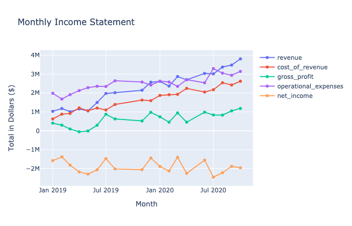

```python
trace1 = go.Scatter(x=monthly_statement.index,
                    y=monthly_statement[['revenue']].revenue,
                    name = 'revenue')

trace2 = go.Scatter(x=monthly_statement.index,
                    y=monthly_statement[['cost_of_revenue']].cost_of_revenue,
                    name = 'cost_of_revenue')

trace3 = go.Scatter(x=monthly_statement.index,
                    y=monthly_statement[['gross_profit']].gross_profit,
                    name = 'gross_profit')

trace4 = go.Scatter(x=monthly_statement.index,
                    y=monthly_statement[['operational_expenses']].operational_expenses,
                    name = 'operational_expenses')

trace5 = go.Scatter(x=monthly_statement.index,
                    y=monthly_statement[['net_income']].net_income,
                    name = 'net_income')

trace6 = go.Scatter(x=monthly_statement.index,
                    y=monthly_statement[['gross_margin']].gross_margin,
                    name = 'gross_margin')

data = [trace1, trace2, trace3, trace4, trace5]
layout = go.Layout(title='Monthly Income Statement',
                   xaxis=dict(title='Month'),
                   yaxis=dict(title='Total in Dollars ($)'),
                   height=800)

fig = go.Figure(data=data, layout=layout)
fig.show("png")
```

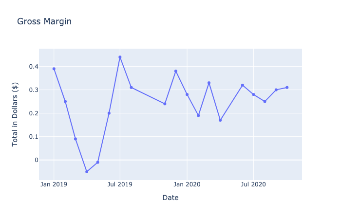

```python
data = [trace6]
layout = go.Layout(title='Gross Margin',
                   xaxis=dict(title='Date'),
                   yaxis=dict(title='Total in Dollars ($)'),
                   height=800)

fig = go.Figure(data=data, layout=layout)
fig.show("png")
```

#### Quick observations and trends based on the above charts:

- Revenue is beginning to overtake Operational Expenses at the beginning of 2020.
- Gross Profit and Net Income remain relatively flat because although Revenue is rising, Cost Of Revenue and Operating Expenses are rising as well.
- For this reason, Gross Margin is also flat.